# Bike_trip_Chicago_2019

Neeraj

2023-01-12

# Problem Statement

In this case study, I use Divvy trips dataset which has data of a bike-sharing company in Chicago during 2019. Analysing the given dataset we aim to design marketing strategies aimed at converting casual riders into annual members.

Data collected from [Divvy_trips](https://divvy-tripdata.s3.amazonaws.com/index.html)

# Importing necessary libraries

```r
library(tidyverse)
library(lubridate)
```

```r
library(ggplot2)
```

# Reading datasets of Bike trips in 2019 over 4 quarters

```r
df1=read_csv("D:/Capstone dataset/Divvy_Trips_2019_Q1.csv")
df2=read_csv("D:/Capstone dataset/Divvy_Trips_2019_Q2.csv")
df3=read_csv("D:/Capstone dataset/Divvy_Trips_2019_Q3.csv")
df4=read_csv("D:/Capstone dataset/Divvy_Trips_2019_Q4.csv")
```

# Making data consistent across all 4 datasets

```r
colnames(df1)
```

```
##  [1] "trip_id"           "start_time"        "end_time"
##  [4] "bikeid"            "tripduration"      "from_station_id"
##  [7] "from_station_name" "to_station_id"     "to_station_name"
## [10] "usertype"          "gender"            "birthyear"
```

```r
colnames(df2)
```

```
##  [1] "01 - Rental Details Rental ID"
##  [2] "01 - Rental Details Local Start Time"
##  [3] "01 - Rental Details Local End Time"
##  [4] "01 - Rental Details Bike ID"
##  [5] "01 - Rental Details Duration In Seconds Uncapped"
##  [6] "03 - Rental Start Station ID"
##  [7] "03 - Rental Start Station Name"
##  [8] "02 - Rental End Station ID"
##  [9] "02 - Rental End Station Name"
## [10] "User Type"
## [11] "Member Gender"
## [12] "05 - Member Details Member Birthday Year"
```

```r
colnames(df3)
```

```
##  [1] "trip_id"           "start_time"        "end_time"
##  [4] "bikeid"            "tripduration"      "from_station_id"
##  [7] "from_station_name" "to_station_id"     "to_station_name"
## [10] "usertype"          "gender"            "birthyear"
```

```r
colnames(df4)
```

```
##  [1] "trip_id"           "start_time"        "end_time"
##  [4] "bikeid"            "tripduration"      "from_station_id"
##  [7] "from_station_name" "to_station_id"     "to_station_name"
## [10] "usertype"          "gender"            "birthyear"
```

```r
df2 <- df2 %>%
  rename(
    trip_id = "01 - Rental Details Rental ID"
          ,bikeid = "01 - Rental Details Bike ID"
          ,start_time = "01 - Rental Details Local Start Time"
          ,end_time = "01 - Rental Details Local End Time"
          ,tripduration=  "01 - Rental Details Duration In Seconds Uncapped"
          ,from_station_name = "03 - Rental Start Station Name"
          ,from_station_id = "03 - Rental Start Station ID"
          ,to_station_name = "02 - Rental End Station Name"
          ,to_station_id = "02 - Rental End Station ID"
          ,usertype = "User Type"
          ,gender="Member Gender"
          ,birthyear= "05 - Member Details Member Birthday Year"
          )
df1 <-  mutate(df1, trip_id = as.character(trip_id)
                   ,bikeid = as.character(bikeid))
df2 <-  mutate(df2, trip_id = as.character(trip_id)
               ,bikeid = as.character(bikeid))
df3 <-  mutate(df3, trip_id = as.character(trip_id)
               ,bikeid = as.character(bikeid))
df4 <-  mutate(df4, trip_id = as.character(trip_id)
               ,bikeid = as.character(bikeid))
```

# Merging the dataset together

```r
all_trips= bind_rows(df1,df2,df3,df4)
colnames(all_trips)
```

```
##  [1] "trip_id"           "start_time"        "end_time"
##  [4] "bikeid"            "tripduration"      "from_station_id"
##  [7] "from_station_name" "to_station_id"     "to_station_name"
## [10] "usertype"          "gender"            "birthyear"
```

```r
dim(all_trips)
```

```
## [1] 3818004      12
```

```r
summary(all_trips)
```

```
##    trip_id            start_time
##  Length:3818004     Min.   :2019-01-01 00:04:37.00
##  Class :character   1st Qu.:2019-05-29 15:49:26.50
##  Mode  :character   Median :2019-07-25 17:50:54.00
##                     Mean   :2019-07-19 21:47:37.11
##                     3rd Qu.:2019-09-15 06:48:05.75
##                     Max.   :2019-12-31 23:57:17.00
##
##     end_time                         bikeid           tripduration
##  Min.   :2019-01-01 00:11:07.00   Length:3818004     Min.   :      61
##  1st Qu.:2019-05-29 16:09:28.25   Class :character   1st Qu.:     411
##  Median :2019-07-25 18:12:23.00   Mode  :character   Median :     709
##  Mean   :2019-07-19 22:11:47.56                      Mean   :    1450
##  3rd Qu.:2019-09-15 08:30:13.25                      3rd Qu.:    1283
##  Max.   :2020-01-21 13:54:35.00                      Max.   :10628400
##
##  from_station_id from_station_name  to_station_id   to_station_name
##  Min.   :  1.0   Length:3818004     Min.   :  1.0   Length:3818004
##  1st Qu.: 77.0   Class :character   1st Qu.: 77.0   Class :character
##  Median :174.0   Mode  :character   Median :174.0   Mode  :character
##  Mean   :201.7                      Mean   :202.6
##  3rd Qu.:289.0                      3rd Qu.:291.0
##  Max.   :673.0                      Max.   :673.0
##
##    usertype            gender            birthyear
##  Length:3818004     Length:3818004     Min.   :1759
##  Class :character   Class :character   1st Qu.:1979
##  Mode  :character   Mode  :character   Median :1987
##                                        Mean   :1984
##                                        3rd Qu.:1992
##                                        Max.   :2014
##                                        NA's   :538751
```

# Data cleaning

```r
all_trips$date <- as.Date(all_trips$start_time)
all_trips$time <- format(as_datetime(all_trips$start_time),"%H")
all_trips$month <- format(as.Date(all_trips$start_time),"%b")
all_trips$day <- format(as.Date(all_trips$start_time),"%d")
all_trips$day_of_week <- format(as.Date(all_trips$start_time),"%A")
str(all_trips)
```

```
## tibble [3,818,004 × 17] (S3: tbl_df/tbl/data.frame)
##  $ trip_id          : chr [1:3818004] "21742443" "21742444" "21742445" "21742446" ...
##  $ start_time       : POSIXct[1:3818004], format: "2019-01-01 00:04:37" "2019-01-01 00:08:13" ...
##  $ end_time         : POSIXct[1:3818004], format: "2019-01-01 00:11:07" "2019-01-01 00:15:34" ...
##  $ bikeid           : chr [1:3818004] "2167" "4386" "1524" "252" ...
##  $ tripduration     : num [1:3818004] 390 441 829 1783 364 ...
##  $ from_station_id  : num [1:3818004] 199 44 15 123 173 98 98 211 150 268 ...
##  $ from_station_name: chr [1:3818004] "Wabash Ave & Grand Ave" "State St & Randolph St" "Racine Ave & 18th St" "California Ave & Milwaukee Ave" ...
##  $ to_station_id    : num [1:3818004] 84 624 644 176 35 49 49 142 148 141 ...
##  $ to_station_name  : chr [1:3818004] "Milwaukee Ave & Grand Ave" "Dearborn St & Van Buren St (*)" "Western Ave & Fillmore St (*)" "Clark St & Elm St" ...
##  $ usertype         : chr [1:3818004] "Subscriber" "Subscriber" "Subscriber" "Subscriber" ...
##  $ gender           : chr [1:3818004] "Male" "Female" "Female" "Male" ...
##  $ birthyear        : num [1:3818004] 1989 1990 1994 1993 1994 ...
##  $ date             : Date[1:3818004], format: "2019-01-01" "2019-01-01" ...
##  $ time             : chr [1:3818004] "00" "00" "00" "00" ...
##  $ month            : chr [1:3818004] "Jan" "Jan" "Jan" "Jan" ...
##  $ day              : chr [1:3818004] "01" "01" "01" "01" ...
##  $ day_of_week      : chr [1:3818004] "Tuesday" "Tuesday" "Tuesday" "Tuesday" ...
```

#selecting only relevant features

```r
df <- select(all_trips,-c(start_time,end_time,bikeid,from_station_id,
                          to_station_id,birthyear))
```

# COMPARE

## trip duration with usertype

```r
aggregate(df$tripduration~df$usertype,FUN = mean)
```

```
##   df$usertype df$tripduration
## 1    Customer       3420.8857
## 2  Subscriber        859.3833
```

```r
aggregate(df$tripduration~df$usertype,FUN = length)
```

```
##   df$usertype df$tripduration
## 1    Customer          880637
## 2  Subscriber         2937367
```

## trip duration with gender

```r
aggregate(df$tripduration~df$gender,FUN = mean)
```

```
##   df$gender df$tripduration
## 1    Female       1304.1320
## 2      Male        987.4869
```

```r
aggregate(df$tripduration~df$gender,FUN = length)
```

```
##   df$gender df$tripduration
## 1    Female          857978
## 2      Male         2400820
```

## trip duration with day_week

```r
#fixing the order
df$day_of_week <- ordered(df$day_of_week, levels=c("Sunday",
            "Monday", "Tuesday", "Wednesday", "Thursday", "Friday", "Saturday"))
aggregate(df$tripduration~df$day_of_week,FUN = mean)
```

```
##   df$day_of_week df$tripduration
## 1         Sunday        1900.408
## 2         Monday        1292.127
## 3        Tuesday        1241.785
## 4      Wednesday        1257.296
## 5       Thursday        1303.871
## 6         Friday        1415.446
## 7       Saturday        1929.782
```

```r
aggregate(df$tripduration~df$day_of_week,FUN = length)
```

```
##   df$day_of_week df$tripduration
## 1         Sunday          426420
## 2         Monday          560269
## 3        Tuesday          585680
## 4      Wednesday          584022
## 5       Thursday          588287
## 6         Friday          578107
## 7       Saturday          495219
```

## trip duration with month

```r
df$month <- ordered(df$month, levels=c("Jan","Feb", "Mar", "Apr", "May", "Jun",
                                       "Jul","Aug","Sep","Oct","Nov","Dec"))
aggregate(df$tripduration~df$month,FUN = mean)
```

```
##    df$month df$tripduration
## 1       Jan        1023.657
## 2       Feb        1021.613
## 3       Mar        1008.720
## 4       Apr        1214.908
## 5       May        1329.303
## 6       Jun        1388.453
## 7       Jul        1805.295
## 8       Aug        1936.238
## 9       Sep        1437.189
## 10      Oct        1308.527
## 11      Nov        1091.974
## 12      Dec        1014.410
```

```r
aggregate(df$tripduration~df$month,FUN = length)
```

```
##    df$month df$tripduration
## 1       Jan          103272
## 2       Feb           96186
## 3       Mar          165611
## 4       Apr          265310
## 5       May          367458
## 6       Jun          475395
## 7       Jul          557315
## 8       Aug          590184
## 9       Sep          493219
## 10      Oct          371786
## 11      Nov          177176
## 12      Dec          155092
```

# ANALYSIS

## ridership data by usertype and weekday

```r
graph_1 <- df %>%
  group_by(usertype,day_of_week) %>%
  summarise(number_of_rides = n(), avg_duration=mean(tripduration)) %>%
  arrange(usertype,day_of_week)
```

#### Number of trips by usertype and weekday

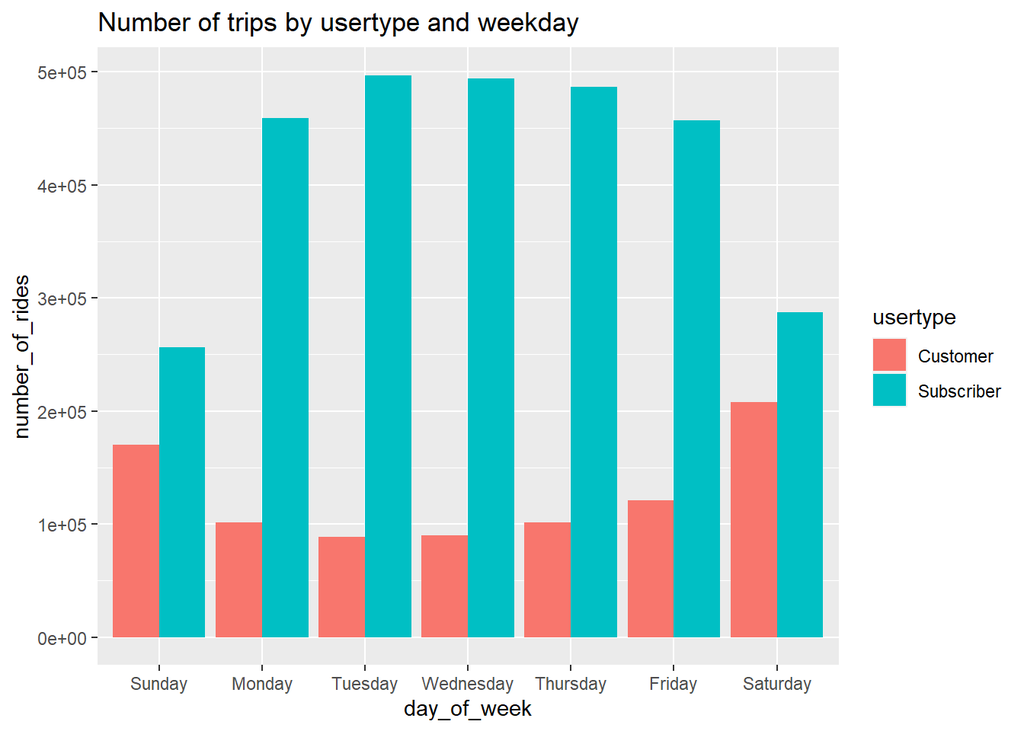

```r
ggplot(data = graph_1, aes(x=day_of_week,y=number_of_rides,fill = usertype)) +
  geom_col(position = "dodge")+labs(title = "Number of trips by usertype and weekday")
```

#### Mean trip duration by usertype and weekday

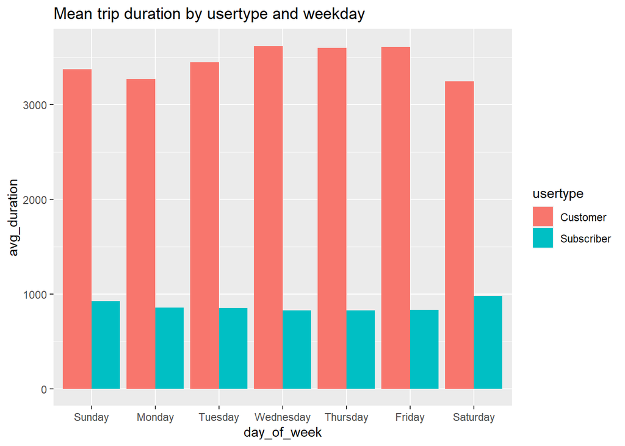

```r
ggplot(data = graph_1, aes(x=day_of_week,y=avg_duration,fill = usertype)) +
  geom_col(position = "dodge")+labs(title = "Mean trip duration by usertype and weekday")
```

## ridership data by gender and weekday

```r
graph_2 <- df %>%
  drop_na(gender) %>%
  group_by(gender,day_of_week) %>%
  summarise(number_of_rides = n(), avg_duration=mean(tripduration)) %>%
  arrange(gender,day_of_week)
```

#### Number of trips by gender and weekday

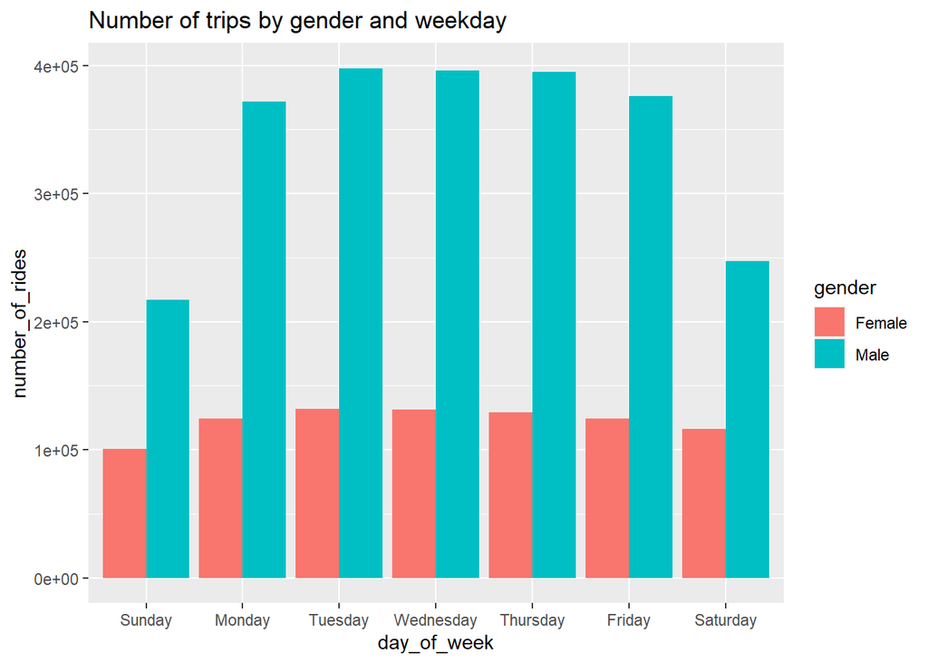

```r
ggplot(data = graph_2, aes(x=day_of_week,y=number_of_rides,fill = gender)) +
  geom_col(position = "dodge")+labs(title = "Number of trips by gender and weekday")
```

#### Mean trip duration by gender and weekday

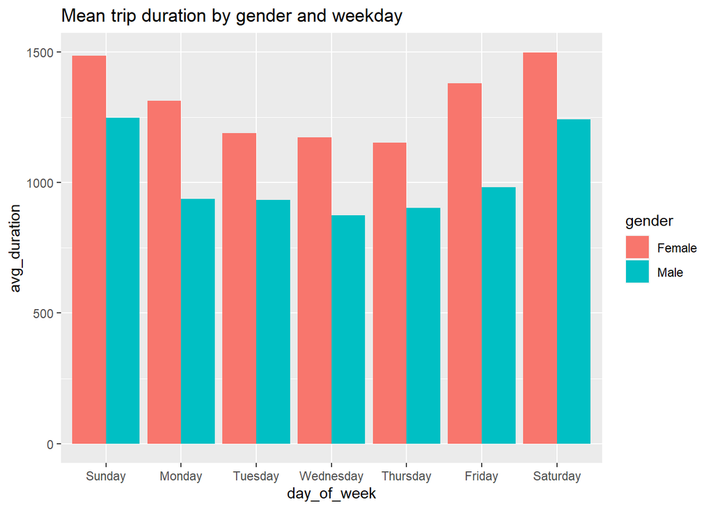

```r
ggplot(data = graph_2, aes(x=day_of_week,y=avg_duration,fill = gender)) +
  geom_col(position = "dodge")+labs(title = "Mean trip duration by gender and weekday")
```

## ridership data by gender and usertype

```r
graph_3 <- df %>%
  drop_na(gender) %>%
  group_by(gender,usertype) %>%
  summarise(number_of_rides = n(), avg_duration=mean(tripduration)) %>%
  arrange(gender,usertype)
```

#### Number of male and female users by usertype

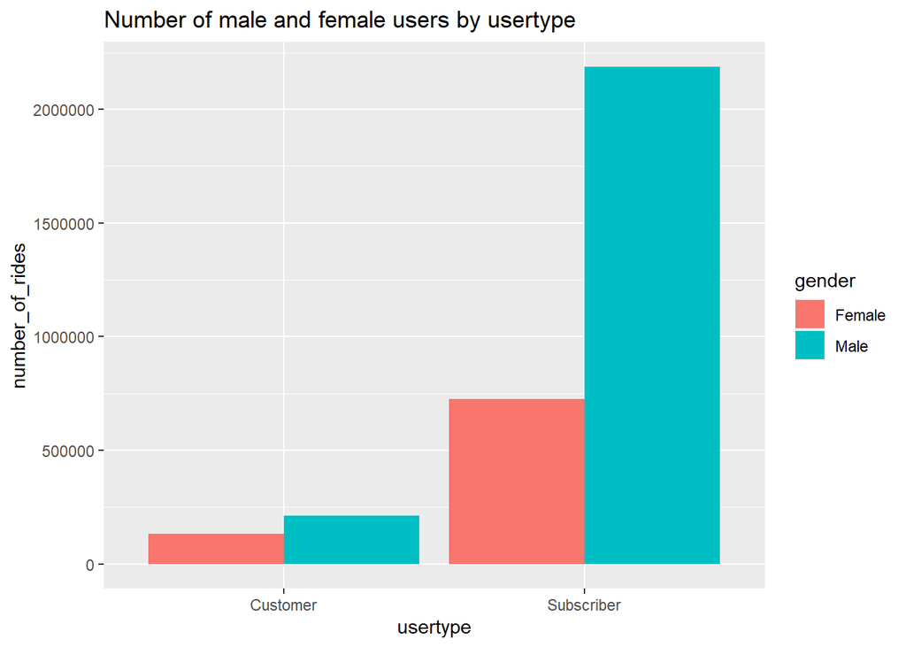

```r
ggplot(data = graph_3, aes(x=usertype,y=number_of_rides,fill = gender)) +
  geom_col(position = "dodge")+labs(title = "Number of male and female users by usertype")
```

## ridership data by week days and months

```r
df$month <- ordered(df$month, levels=c("Jan","Feb", "Mar", "Apr", "May", "Jun",
                                       "Jul","Aug","Sep","Oct","Nov","Dec"))
df$day_of_week <- ordered(df$day_of_week, levels=c("Sunday", "Monday", "Tuesday",
                                  "Wednesday", "Thursday", "Friday", "Saturday"))
graph_4 <- df %>%
  group_by(day_of_week,month,usertype) %>%
  summarise(number_of_rides = n(), avg_duration=mean(tripduration)) %>%
  arrange(day_of_week,month)
```

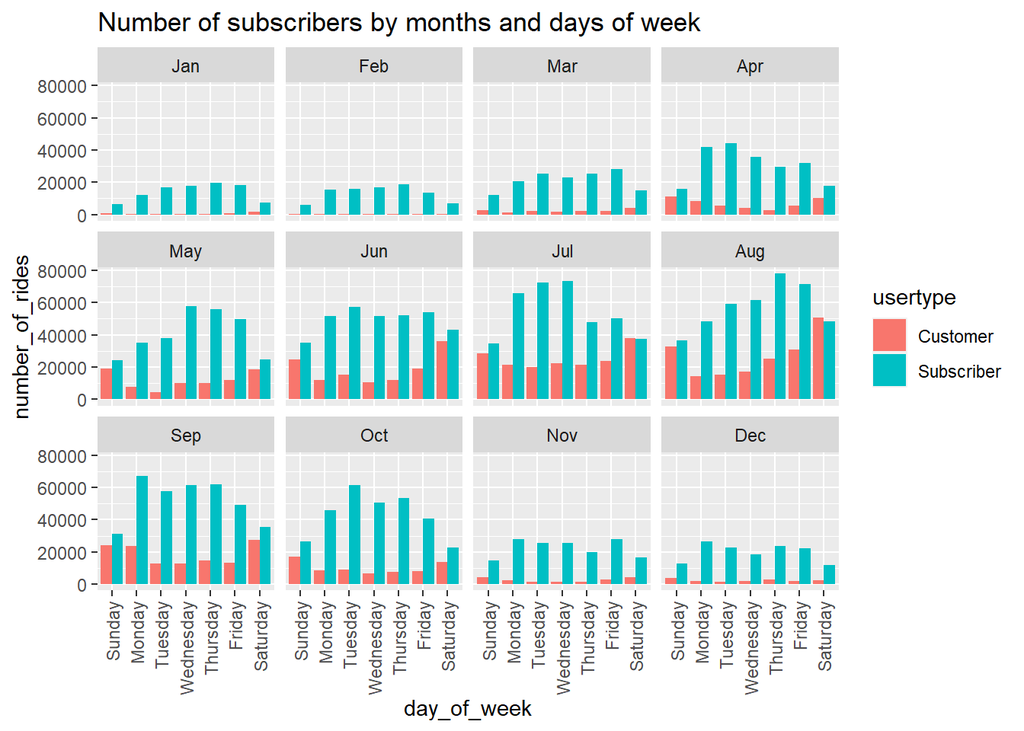

```r
ggplot(data = graph_4, aes(x=day_of_week,y=number_of_rides, fill = usertype)) +
  geom_col(position = "dodge")+
  facet_wrap(~month)+
  theme(axis.text.x = element_text(angle = 90, vjust = 0.5, hjust=1))+
  labs(title = "Number of subscribers by months and days of week")
```

## ridership data by week days and time

```r
df$day_of_week <- ordered(df$day_of_week, levels=c("Sunday",
                                                   "Monday", "Tuesday", "Wednesday", "Thursday", "Friday", "Saturday"))
graph_5 <- df %>%
  group_by(day_of_week,time) %>%
  summarise(number_of_rides = n(), avg_duration=mean(tripduration)) %>%
  arrange(day_of_week,time)
```

#### Number of trips by time and days of week

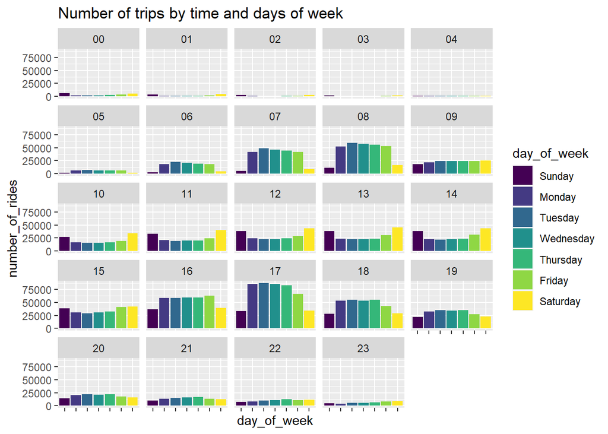

```r
ggplot(data = graph_5, aes(x=day_of_week,y=number_of_rides, fill = day_of_week)) +
  geom_col(position = "dodge")+
  facet_wrap(~time)+
  theme(axis.text.x = element_blank())+
  labs(title = "Number of trips by time and days of week")
```

# Observations

- From this plot , we can see that number of rides for subscribers increase through working days and decreases on the weekends. While the customer number is high on weekends.
- From this plot , we can see that ride duration is high for customers than subscribers.
- From this plot , we can see that number of male riders increases through workdays and is at the lowest on weekends. Number of females riders are low compared to male riders and is fairly consistent throughout the week.
- Here , Average ride duration is higher for females compared to males and it is high on weekends and decreases through the working days.
- This plot shows that there are less number of female subscribers for the company.
- From this plot , we can see that subscriptions start to increase from the month of April to October and is low on the months from November to March.
- Here , we can see that the number of riders start to increase from morning 6 am, reaches a peak at 8 am, then decrease mid day and then again reaches peak at 4pm to 6pm, then decreases again.

# Conclusion

- To increase the subscribers on weekends, weekend specific offers and discounts for subscribers taking bikes from/to entertainment centers or recreational activities should be introduced.
- Provide special subscription offers to customers who have ride duration over a certain limit.
- Advertisements and campaigns to increase the number of female users should be introduced.
- Advertisements and discounts should be increased on the months from november to march to increase the number of users during this period.